# Analysis of PlanetTerp Data

### Suruchi Walekar, Nihar Chegireddy, Christopher Tark

## Introduction

The [data science pipeline](https://www.domo.com/glossary/what-is-the-data-science-pipeline) consists of carefully curating and processing data, performing exploratory data analysis, forming hypotheses, and testing them using models to arrive at insights that could help solve problems or clarify patterns. While data science can be used for large-scale, technical analysis and innovation, it can also highlight trends and reveal relationships between variables in everyday life.

As students at the University of Maryland, we utilize PlanetTerp, a website designed to help students make informed decisions by providing aggregated data about courses, grades, and professors at the school. Information about the courses comes from umd.io, an open source API for UMD data. We wanted to use data science techniques and methodology to take a deep dive into the information provided by PlanetTerp and find insights regarding potential relationships between variables such as a class's average GPA, a class's department, professors' star ratings, the positivity of reviews, and how ratings and grades have changed over time.

Why is this important? This type of analysis can help shed light on the trustworthiness and accuracy of websites such as PlanetTerp and also help gain an understanding of patterns and changes over the years at the school. Since UMD is a large public university with a diverse student body, the results could be representative of and potentially generalized to similar universities. The website itself already has some excellent insights, such as an interactive chart showing grade inflation, or how average GPAs have increased over time in essentially every department. This illuminates trends in higher education as a whole using UMD as a microcosm of the nation's universities, and we hope to find similar patterns in other variables.

Table of Contents:

1. Data Collection
2. Data Processing
3. Exploratory Data Analysis
4. Machine Learning and Hypothesis Testing
5. Conclusion and Interpretation

## Data Collection

In this section, we will [scrape data](https://www.geeksforgeeks.org/python-requests-tutorial/) from [PlanetTerp](https://planetterp.com/) using the [API](https://planetterp.com/api/) endpoints, collecting information for all classes, professors, and grade data and storing it into dataframes for later use.

```python
#Install needed imports
%%capture
%pip install pandas
%pip install numpy
%pip install tqdm
%pip install matplotlib
%pip install scikit-learn
```

```python
import pandas as pd
import numpy as np
from google.colab import files
import matplotlib.pyplot as plt
import requests
import json
import time
from sklearn.linear_model import Ridge
from sklearn.model_selection import train_test_split
from sklearn.metrics import mean_squared_error
from sklearn.linear_model import LinearRegression
from sklearn import neighbors
from tqdm import tqdm
import ast
import statsmodels.api as sm
```

```python
#Collect courses data (do NOT run while testing)
all_courses = []
base_url = "https://api.planetterp.com/v1/courses"
offset = 100

#Keep intervals between requests for rate limiting to avoid crashes
current = requests.get(base_url + "?reviews=true&limit=100&offset=0").json()
time.sleep(0.1)
all_courses.extend(current)

while len(current) == 100:
  current = requests.get(base_url + "?reviews=true&limit=100&offset=" + str(offset)).json()
  time.sleep(0.1)
  all_courses.extend(current)
  offset += 100

courses = pd.json_normalize(all_courses)
```

```python
#Collect professor data (do NOT run while testing)
all_professors = []
base_url = "https://api.planetterp.com/v1/professors"
offset = 100

#Keep intervals between requests for rate limiting to avoid crashes
current = requests.get(base_url + "?type=professor&reviews=true&limit=100&offset=0").json()
time.sleep(0.1)
all_professors.extend(current)

while len(current) == 100:
  current = requests.get(base_url + "?type=professor&reviews=true&limit=100&offset=" + str(offset)).json()
  time.sleep(0.1)
  all_professors.extend(current)
  offset += 100

professors = pd.json_normalize(all_professors)
```

Now that we have the data for courses and professors, we can get the grade data based on the courses.

```python
#Collect grade data (do NOT run while testing)
course_names = courses["name"]
all_grades = []
base_url = "https://api.planetterp.com/v1/grades"
offset = 100

#Keep intervals between requests for rate limiting to avoid crashes
for name in tqdm(course_names):
  current = requests.get(base_url + "?course=" + name).json()
  time.sleep(0.1)
  all_grades.extend(current)

grades = pd.json_normalize(all_grades)
```

```python
#Download data to a local CSV file for testing purposes to avoid long scraping time
#(do NOT run while testing)
courses.to_csv('courses.csv', index=False)
files.download('courses.csv')
```

```python
professors.to_csv('professors.csv', index=False)
files.download('professors.csv')
```

```python
grades.to_csv('grades.csv', index=False)
files.download('grades.csv')
```

```python
# Only run this while testing, load in data from CSV files
courses = pd.read_csv('courses.csv')
professors = pd.read_csv('professors.csv')
grades = pd.read_csv('grades.csv')
```

```python
#Show samples of the data collected so far
courses.head()
```

|  | average_gpa | professors | reviews | department | course_number | name | title | credits | description | is_recent | geneds |
| --- | --- | --- | --- | --- | --- | --- | --- | --- | --- | --- | --- |
| 0 | 3.713869 | ['Jordan Boyd-Graber', 'A Seyed', 'Vanessa Fri... | [] | INST | 737 | INST737 | Introduction to Data Science | 3.0 | <b>Prerequisite:</b> INST627 and (LBSC690, LBS... | True | NaN |
| 1 | NaN | ['Aaron Goldman', 'Mark Hill', 'Robert DiLutis... | [] | MUSC | 800W | MUSC800W | Advanced Seminar in Music Pedagogy | 3.0 | <b>Prerequisite:</b> MUSC400; or students who ... | True | NaN |
| 2 | NaN | ['Leigh Smiley', 'Scot Reese', 'Izumi Ashizawa... | [] | THET | 499 | THET499 | Independent Study | 1.0 | NaN | True | NaN |
| 3 | 3.463249 | ['Qin Wang', 'Abani Pradhan', 'Solmaz Alborzi'... | [{'professor': 'Shraddha Karanth', 'course': '... | NFSC | 112 | NFSC112 | Food: Science and Technology | 3.0 | Introduction to the realm of food science, foo... | True | NaN |
| 4 | 3.923333 | ['Abani Pradhan', 'Abani Pradhan', 'Abani Prad... | [] | NFSC | 679R | NFSC679R | Selected Topics in Food Science; Food Safety a... | 4.0 | NaN | True | NaN |

```python
professors.head()
```

|  | courses | average_rating | type | reviews | name | slug |
| --- | --- | --- | --- | --- | --- | --- |
| 0 | ['INST737', 'ENPM808W', 'ENPM808W', 'ENPM808W'... | NaN | professor | [] | A Seyed | seyed |
| 1 | ['MUSC800W', 'MUSC830W', 'MUSC830W', 'MUSC830W'] | NaN | professor | [] | Aaron Goldman | goldman_aaron |
| 2 | ['THET678', 'THET499'] | NaN | professor | [] | Aaron Posner | posner |
| 3 | ['NFSC431', 'NFSC679R', 'NFSC112', 'HLTH672', ... | 3.6667 | professor | [{'professor': 'Abani Pradhan', 'course': None... | Abani Pradhan | pradhan |
| 4 | ['CMLT235', 'ENGL101', 'ENGL234', 'ENGL101H', ... | NaN | professor | [] | Abbey Morgan | morgan_abbey |

```python
grades.head()
```

|  | course | professor | semester | section | A+ | A | A- | B+ | B | B- | C+ | C | C- | D+ | D | D- | F | W | Other |
| --- | --- | --- | --- | --- | --- | --- | --- | --- | --- | --- | --- | --- | --- | --- | --- | --- | --- | --- | --- |
| 0 | INST737 | Jordan Boyd-Graber | 201301 | 0101 | 4 | 8 | 4 | 4 | 2 | 0 | 0 | 1 | 0 | 0 | 0 | 0 | 0 | 4 | 6 |
| 1 | INST737 | Jordan Boyd-Graber | 201401 | 0101 | 9 | 7 | 6 | 4 | 3 | 1 | 0 | 0 | 0 | 0 | 0 | 0 | 0 | 1 | 0 |
| 2 | INST737 | NaN | 201408 | 0101 | 6 | 13 | 6 | 6 | 0 | 0 | 0 | 0 | 0 | 0 | 0 | 0 | 0 | 1 | 0 |
| 3 | INST737 | NaN | 201501 | SG01 | 2 | 4 | 0 | 2 | 0 | 0 | 0 | 0 | 0 | 0 | 0 | 0 | 0 | 1 | 0 |
| 4 | INST737 | A Seyed | 201508 | 0101 | 18 | 9 | 0 | 1 | 0 | 0 | 0 | 0 | 0 | 0 | 0 | 0 | 0 | 0 | 0 |

## Data Processing

Now that we have all of the data from PlanetTerp, we can process it into a more usable and understandable format with the help of [Pandas](https://pandas.pydata.org/docs/reference/general_functions.html) and [NumPy](https://numpy.org/doc/stable/reference/) functions. Let's see the distribution of missing values for the courses and professors tables.

```python
courses.isnull().sum()
```

```
average_gpa       2744
professors           0
reviews              0
department           0
course_number        0
name                 0
title             2601
credits           2601
description       5696
is_recent            0
geneds           15682
dtype: int64
```

```python
professors.isnull().sum()
```

```
courses              0
average_rating    9036
type                 0
reviews              0
name                 0
slug                 0
dtype: int64
```

For courses, missing data for average GPA will need to be handled since it is necessary for analysis later, but the title, credits, and description columns can be dropped and do not need to be accounted for in terms of handling missingness. The columns for course_number and is_recent can also be dropped since they are not relevant for analysis.

```python
#Reorganize table to only keep columns that will be analyzed later
courses = courses[['name', 'average_gpa', 'department', 'professors', 'reviews']]
courses.head(3)
```

|  | name | average_gpa | department | professors | reviews |
| --- | --- | --- | --- | --- | --- |
| 0 | INST737 | 3.713869 | INST | ['Jordan Boyd-Graber', 'A Seyed', 'Vanessa Fri... | [] |
| 1 | MUSC800W | NaN | MUSC | ['Aaron Goldman', 'Mark Hill', 'Robert DiLutis... | [] |
| 2 | THET499 | NaN | THET | ['Leigh Smiley', 'Scot Reese', 'Izumi Ashizawa... | [] |

Data for professors can be recorganized similarly to only keep the columns that are relevant for analysis, since the type column has only true values and the slug column is used as an identifier and is not needed.

```python
#Reorganize table to only keep columns that will be analyzed later
professors = professors[['name', 'average_rating', 'courses', 'reviews']]

#add column for number of courses
pd.options.mode.chained_assignment = None
professors['courses'] = professors['courses'].apply(ast.literal_eval)
professors['courses'] = professors['courses'].apply(lambda x: list(set(x)))
professors['num_courses'] = professors['courses'].apply(lambda x: len(x))

professors['reviews'] = professors['reviews'].apply(ast.literal_eval)
professors['num_reviews'] = professors['reviews'].apply(lambda x: len(x))

professors.head(3)
```

|  | name | average_rating | courses | reviews | num_courses | num_reviews |
| --- | --- | --- | --- | --- | --- | --- |
| 0 | A Seyed | NaN | [ENPM606, INST737, ENPM808W] | [] | 3 | 0 |
| 1 | Aaron Goldman | NaN | [MUSC800W, MUSC830W] | [] | 2 | 0 |
| 2 | Aaron Posner | NaN | [THET678, THET499] | [] | 2 | 0 |

Data for grades should be fine for now since it is already arranged in a reasonable order and all of the columns are useful, but another column can be added for the numeric grade.

```python
grades['gpa'] = (4.0*grades['A+'] + 4.0*grades['A'] + 3.7*grades['A-'] + 3.3*grades['B+'] + 3.0*grades['B'] +
                 2.7*grades['B-'] + 2.3*grades['C+'] + 2.0*grades['C'] + 1.7*grades['C-'] + 1.3*grades['D+'] + 1.0*grades['D'] +
                 0.7*grades['D-'])/(grades['A+'] + grades['A'] + grades['A-'] + grades['B+'] + grades['B'] + grades['B-'] +
                                    grades['C+'] + grades['C'] + grades['C-'] + grades['D+'] + grades['D'] + grades['D-'] +
                                    grades['F'] + grades['W'])
grades.head(3)
```

|  | course | professor | semester | section | A+ | A | A- | B+ | B | B- | C+ | C | C- | D+ | D | D- | F | W | Other | gpa |
| --- | --- | --- | --- | --- | --- | --- | --- | --- | --- | --- | --- | --- | --- | --- | --- | --- | --- | --- | --- | --- |
| 0 | INST737 | Jordan Boyd-Graber | 201301 | 0101 | 4 | 8 | 4 | 4 | 2 | 0 | 0 | 1 | 0 | 0 | 0 | 0 | 0 | 4 | 6 | 3.111111 |
| 1 | INST737 | Jordan Boyd-Graber | 201401 | 0101 | 9 | 7 | 6 | 4 | 3 | 1 | 0 | 0 | 0 | 0 | 0 | 0 | 0 | 1 | 0 | 3.583871 |
| 2 | INST737 | NaN | 201408 | 0101 | 6 | 13 | 6 | 6 | 0 | 0 | 0 | 0 | 0 | 0 | 0 | 0 | 0 | 1 | 0 | 3.687500 |

### Accounting for Missing Data

When datasets have missing data, there are a variety of ways to handle it. Three types of [missing data](https://www.ncbi.nlm.nih.gov/books/NBK493614/) are Missing Completely At Random, when the missingness of data does not have a pattern or dependence on observed or unobserved variables, Missing At Random, where missing data can be explained by other observed variables, and Missing Not At Random, where the value of missing data has to do with why it is missing.

In the case of the GPA data, there are 2744 cases where the average GPA was not provided. However, this is not connected to any of the other variables such as names, department, professors, or reviews. Grade data is obtained for PlanetTerp from the Office of Institutional Research, Planning, and Assessment through a Public Information Request, and the steps of this process are independent of the observed and unobserved variables, making the data close to Missing Completely At Random rather than following an established pattern. Because of this, we can elect to drop the rows without GPAs, since the missing data is spread out across departments and should not create substantial bias in the results.

```python
courses = courses.dropna()
courses.head(3)
```

|  | name | average_gpa | department | professors | reviews |
| --- | --- | --- | --- | --- | --- |
| 0 | INST737 | 3.713869 | INST | ['Jordan Boyd-Graber', 'A Seyed', 'Vanessa Fri... | [] |
| 3 | NFSC112 | 3.463249 | NFSC | ['Qin Wang', 'Abani Pradhan', 'Solmaz Alborzi'... | [{'professor': 'Shraddha Karanth', 'course': '... |
| 4 | NFSC679R | 3.923333 | NFSC | ['Abani Pradhan', 'Abani Pradhan', 'Abani Prad... | [] |

Similarly, the data for missing ratings for professors is hard to classify. Ratings are only present based on reviews, and students may choose not to review professors for a variety of reasons. It is extremely difficult to estimate the rating for a professor because the fact that the professor is not reviewed would not be related to the other variables being measured such as their name or the courses that they teach. Because of this, even though the majority of professors are missing ratings/reviews, we will only use the subset of professors that do have ratings, since the reasons for the missing ratings are unknown and cannot be modeled.

```python
professors = professors.dropna()
professors.head(3)
```

|  | name | average_rating | courses | reviews | num_courses | num_reviews |
| --- | --- | --- | --- | --- | --- | --- |
| 3 | Abani Pradhan | 3.6667 | [HLTH672, NFSC672, NFSC112, HLTH710, NFSC679R,... | [{'professor': 'Abani Pradhan', 'course': None... | 6 | 3 |
| 6 | Abhijit Dasgupta | 4.2500 | [ENAE202, ENMA300, ENME473, ENRE600, ENME684, ... | [{'professor': 'Abhijit Dasgupta', 'course': '... | 18 | 4 |
| 8 | Abigail McEwen | 2.6250 | [ARTH262, ARTH386, ARTH799, ARTH488F, ARTH389K... | [{'professor': 'Abigail McEwen', 'course': Non... | 20 | 8 |

For professors, ratings and reviews are present or absent together since the rating does not exist without reviews. However, for courses, all the other variables can be present without reviews having to be present. It cannot truly be said that course reviews are Missing At Random since they cannot be explained entirely by the other variables like GPA, but the average grade of a course might have an effect on whether or not students leave reviews and the sentiment of the reviews. Because of this, we will create two new tables for the courses, with one having only reviewed data and another set with a column saying whether or not a review is present.

```python
reviewed_courses = courses[courses['reviews'].apply(lambda x: len(x) > 2)]
```

```python
courses['has_reviews'] = courses['reviews'].apply(lambda x: len(x) > 2)
courses['professors'] = courses['professors'].apply(ast.literal_eval)
courses['professors'] = courses['professors'].apply(lambda x: list(set(x)))
courses.drop(columns='reviews', inplace=True)
courses.head(3)
```

|  | name | average_gpa | department | professors | has_reviews |
| --- | --- | --- | --- | --- | --- |
| 0 | INST737 | 3.713869 | INST | [Geoffrey Malafsky, David Patrick, A Seyed, Jo... | False |
| 3 | NFSC112 | 3.463249 | NFSC | [Solmaz Alborzi, Yangming Lo, Abani Pradhan, Q... | True |
| 4 | NFSC679R | 3.923333 | NFSC | [Abani Pradhan] | False |

```python
# Properly parse values into lists and dictionaries so they can be accessed better
pd.options.mode.chained_assignment = None
reviewed_courses['professors'] = reviewed_courses['professors'].apply(ast.literal_eval)
reviewed_courses['professors'] = reviewed_courses['professors'].apply(lambda x: list(set(x)))
reviewed_courses['reviews'] = reviewed_courses['reviews'].apply(ast.literal_eval)
```

```python
# Tidy up the reviews dataframe
data = []
for x in reviewed_courses['reviews']:
  for y in x:
    data.append([y['professor'], y['course'],y['review'],y['rating'],y['expected_grade'], y['created']])

reviews = pd.DataFrame(data)
reviews = reviews.rename(columns={0: 'professor', 1: 'course', 2: 'reviews', 3: 'rating', 4: 'grade', 5: 'time'})

reviews.head(3)
```

|  | professor | course | reviews | rating | grade | time |
| --- | --- | --- | --- | --- | --- | --- |
| 0 | Shraddha Karanth | NFSC112 | She's always really prepared for class and not... | 5 | A- | 2020-12-04T21:50:34Z |
| 1 | Qin Wang | NFSC112 | Super chill class, do the study guide slides a... | 5 | A+ | 2021-12-31T18:34:38Z |
| 2 | Qin Wang | NFSC112 | She's alright. Kinda boring since all she does... | 3 | B+ | 2022-12-11T04:16:47.292924Z |

```python
#Add a column to courses for average review rating
average_ratings = reviews.groupby('course')['rating'].mean().to_frame().reset_index()
reviewed_courses = pd.merge(reviewed_courses, average_ratings, left_on='name', right_on='course', how='inner')
reviewed_courses = reviewed_courses[['name', 'average_gpa', 'department', 'professors', 'reviews', 'rating']]
reviewed_courses = reviewed_courses.rename(columns={'rating': 'class_rating'})
reviewed_courses.head(3)
```

|  | name | average_gpa | department | professors | reviews | class_rating |
| --- | --- | --- | --- | --- | --- | --- |
| 0 | NFSC112 | 3.463249 | NFSC | [Solmaz Alborzi, Yangming Lo, Abani Pradhan, Q... | [{'professor': 'Shraddha Karanth', 'course': '... | 4.300000 |
| 1 | AASP298L | 2.300000 | AASP | [Elizabeth Catchmark, Isis Semaj-Hall, Tyra Gr... | [{'professor': 'Zita Nunes', 'course': 'AASP29... | 4.333333 |
| 2 | ENGL101H | 3.553080 | ENGL | [Emily Lyons, Lara Payne, Peter Witte, Samanth... | [{'professor': 'Justin Lohr', 'course': 'ENGL1... | 4.022727 |

We can create another merged dataset that combines some of the information for easier access and analysis.

```python
# Explode the 'courses' column in professors
professors_exploded = professors.explode('courses')

# Merge on the 'name' and 'courses' columns
merged_data = pd.merge(courses, professors_exploded, left_on='name', right_on='courses', how='inner')

merged_data.drop('name_x', axis=1, inplace=True)
merged_data.drop('professors', axis=1, inplace=True)
merged_data.drop('reviews', axis=1, inplace=True)
merged_data.drop('has_reviews', axis=1, inplace=True)

new_column_order = ['courses', 'department', 'name_y', 'average_gpa', 'average_rating', 'num_courses', 'num_reviews']
merged_data = merged_data.reindex(columns=new_column_order)
merged_data = merged_data.rename(columns={'courses': 'course', 'name_y': 'professor', 'average_gpa': 'class_gpa',
'average_rating': 'professor_rating'})

merged_data.head(5)
```

|  | course | department | professor | class_gpa | professor_rating | num_courses | num_reviews |
| --- | --- | --- | --- | --- | --- | --- | --- |
| 0 | INST737 | INST | Jordan Boyd-Graber | 3.713869 | 3.0000 | 13 | 2 |
| 1 | INST737 | INST | David Patrick | 3.713869 | 4.0000 | 13 | 3 |
| 2 | INST737 | INST | Naeemul Hassan | 3.713869 | 4.2500 | 16 | 4 |
| 3 | NFSC112 | NFSC | Abani Pradhan | 3.463249 | 3.6667 | 6 | 3 |
| 4 | NFSC112 | NFSC | Qin Wang | 3.463249 | 4.5000 | 9 | 6 |

## Exploratory Data Analysis

After data processing, the next step of the data science pipeline is exploratory data analysis. We can graph different variables in the datasets that we have gathered to see if there are any visible relationships in the data to explore further, using the [Matplotlib library](https://matplotlib.org/stable/api/index.html) and [Statsmodels](https://www.statsmodels.org/stable/api.html). Examples of relationships we are looking for include linear and exponential relationships as well as clustering. If any of these are found, we can train a model to extrapolate data based on the existing dataset. The variables to investigate include average GPA for classes, rating for professors, number of reviews, and departments.

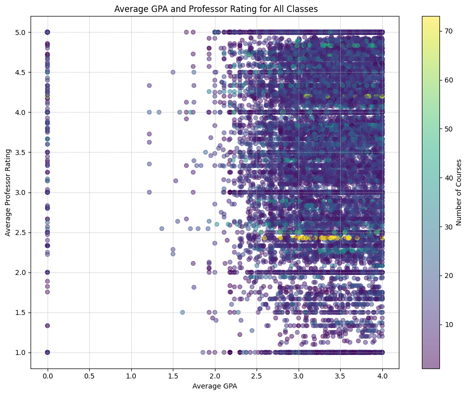

```python
#Graph for GPA and professor rating
plt.figure(figsize=(10, 8))
plt.scatter(merged_data['class_gpa'], merged_data['professor_rating'], alpha=0.5, c=merged_data['num_courses'],
            cmap='viridis')
plt.colorbar(label='Number of Courses')

#Adding grid lines for better readability
plt.grid(True, linestyle='--', linewidth=0.5)

plt.xlabel('Average GPA')
plt.ylabel('Average Professor Rating')
plt.title(' Average GPA and Professor Rating for All Classes')
plt.tight_layout()  #Adjust layout

plt.show()
```

The above scatterplot shows the distribution of the class GPA and professor rating for each possible pairing of class and professor. Each point represents a class with a given professor, with its color indicating the number of courses that professor has taught.

There is a concentration of data points in the higher end of the GPAs, around 2.7 to 4.0, and professor ratings, around 2.5 to 5.0. While there is significant variation, courses with higher GPAs somewhat tend to have higher professor ratings.

There are many courses with a GPA value of 0.0, which could be due to courses that do not assign traditional grades, such as pass/fail or audit courses.

The color gradient, from purple to yellow, indicates how many courses a professor has taught. One observation that can be made is a line of yellow around the 2.5 rating mark, which could all be the same professor.

There are fewer courses with very low GPAs below 2.0 and low professor ratings below 2.5. While this graph is one way to look at the data, it could be conflating multiple variables, so we can see if there is a more visible relationship between any other combinations of variables.

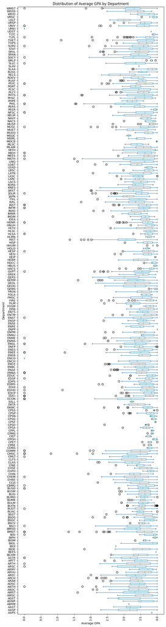

```python
boxplt = courses.boxplot(column='average_gpa', by='department', grid=False, vert=False, figsize=(8,30))
plt.xlabel('Average GPA')
plt.ylabel('Department')
plt.title('Distribution of Average GPA by Department')
plt.xticks(rotation=90)
plt.suptitle('')
plt.tight_layout()
plt.show()
```

The above graph shows the distribution of class GPAs by department, and highlights the variation in grade distribution across UMD using boxplots. The midline of each box is the median, with the box showing the interquartile range and the line showing the minimum and maximum without outliers, which are represented as circles. Some departments have very small ranges, which could mean more consistant grading, and others have very large ones. The discrepancy could also have to do with the size or recency of the department. Courses with very low GPAs tend to be outliers. The median tends to stay between 3.0 and 4.0 with a few exceptions.

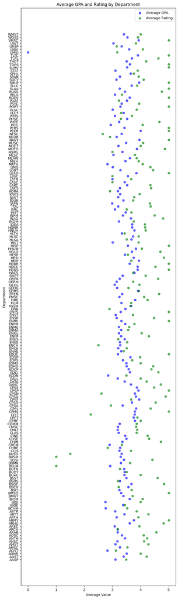

```python
department_avg_gpa = reviewed_courses.groupby('department')['average_gpa'].mean()
department_avg_rating = reviewed_courses.groupby('department')['class_rating'].mean()

plt.figure(figsize=(8, 30))

plt.scatter(department_avg_gpa.values, department_avg_gpa.index, color='blue', alpha=0.6, label='Average GPA')
plt.scatter(department_avg_rating.values, department_avg_rating.index, color='green', alpha=0.6, label='Average Rating')

plt.ylabel('Department')
plt.xlabel('Average Value')
plt.title('Average GPA and Rating by Department')
plt.yticks(ticks=range(len(department_avg_gpa.index)), labels=department_avg_gpa.index)
plt.legend()

plt.show()
```

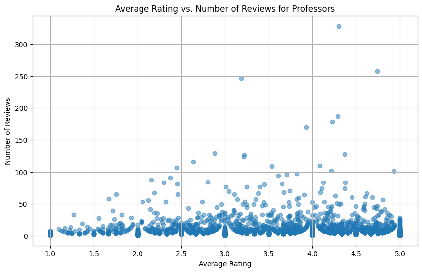

```python
#Plot the average rating vs. the number of reviews
plt.figure(figsize=(10, 6))
plt.scatter(professors['average_rating'], professors['num_reviews'], alpha=0.5)
plt.title('Average Rating vs. Number of Reviews for Professors')
plt.xlabel('Average Rating')
plt.ylabel('Number of Reviews')
plt.grid(True)
plt.show()
```

The above scatterplot shows the number of reviews for professors plotted against the professors' average rating. While there is not a very strong relationship between these variables, there does seem to be a weak linear association between rating and number of reviews. We can test this using ordinary least squares to see if there is any correlation.

```python
model = sm.OLS(professors['num_reviews'], professors['average_rating'])
results = model.fit()
results.summary()
```

OLS Regression Results

| Dep. Variable: | num_reviews | R-squared (uncentered): | 0.166 |
| --- | --- | --- | --- |
| Model: | OLS | Adj. R-squared (uncentered): | 0.166 |
| Method: | Least Squares | F-statistic: | 730.4 |
| Date: | Sat, 18 May 2024 | Prob (F-statistic): | 7.25e-147 |
| Time: | 13:34:02 | Log-Likelihood: | -15243. |
| No. Observations: | 3674 | AIC: | 3.049e+04 |
| Df Residuals: | 3673 | BIC: | 3.049e+04 |
| Df Model: | 1 |  |  |
| Covariance Type: | nonrobust |  |  |

|  | coef | std err | t | P>\|t\| | [0.025 | 0.975] |
| --- | --- | --- | --- | --- | --- | --- |
| average_rating | 1.6814 | 0.062 | 27.025 | 0.000 | 1.559 | 1.803 |

| Omnibus: | 5155.828 | Durbin-Watson: | 1.947 |
| --- | --- | --- | --- |
| Prob(Omnibus): | 0.000 | Jarque-Bera (JB): | 1881789.076 |
| Skew: | 8.064 | Prob(JB): | 0.00 |
| Kurtosis: | 112.693 | Cond. No. | 1.00 |

Notes:  
[1] R² is computed without centering (uncentered) since the model does not contain a constant.  
[2] Standard Errors assume that the covariance matrix of the errors is correctly specified.

Based on the OLS regression results, while the R^2 value is relatively low at 0.166, the p-value for the average_rating variable is 0.000, which can be interpreted to mean that there is a significant relationship between rating and number of reviews. However, because of the weak nature of the relationship, this is not the best hypothesis to proceed with for machine learning, as most classes have a limited number of reviews and rating would not be an accurate predictor of reviews.

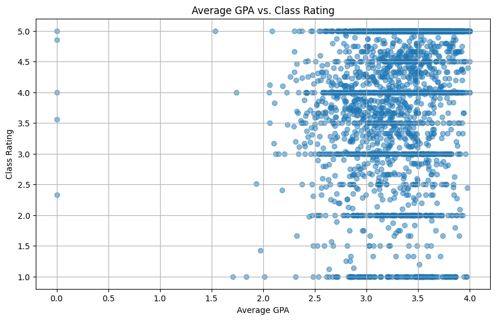

```python
#Average Class GPA vs Rating
plt.figure(figsize=(10, 6))
plt.scatter(reviewed_courses['average_gpa'], reviewed_courses['class_rating'], alpha=0.5)
plt.title('Average GPA vs. Class Rating')
plt.xlabel('Average GPA')
plt.ylabel('Class Rating')
plt.grid(True)
plt.show()
```

The above scatterplot shows the relationship between the average GPA of a class and the average rating of all the professors in the class. Similar to the earlier graph using the merged dataset but more clearly visible due to only using the reviewed courses, reviews tend to be more dense along whole numbers and in the upper right quadrant of the graph with higher ratings and higher GPAs. This could mean that there is a weak association between average GPA and class rating, but it is difficult to evaluate this relationship because there can be many factors contributing to the variance between professors.

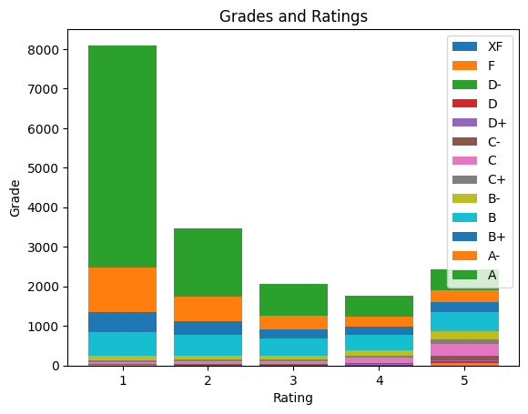

```python
grade_dict = {}

grade_dict['XF'] = 13
grade_dict['F'] = 12
grade_dict['D-'] = 11
grade_dict['D'] = 10
grade_dict['D+'] = 9
grade_dict['C-'] = 8
grade_dict['C'] = 7
grade_dict['C+'] = 6
grade_dict['B-'] = 5
grade_dict['B'] = 4
grade_dict['B+'] = 3
grade_dict['A-'] = 2
grade_dict['A'] = 1
grade_dict['A+'] = 0

star1 = [0,0,0,0,0,0,0,0,0,0,0,0,0,0]
star2 = [0,0,0,0,0,0,0,0,0,0,0,0,0,0]
star3 = [0,0,0,0,0,0,0,0,0,0,0,0,0,0]
star4 = [0,0,0,0,0,0,0,0,0,0,0,0,0,0]
star5 = [0,0,0,0,0,0,0,0,0,0,0,0,0,0]
stars = [star1, star2, star3, star4, star5]


for index, row in reviews.iterrows():
  if row['grade'] in grade_dict.keys():
    stars[row['rating'] - 1][grade_dict[row['grade']]] = stars[row['rating'] - 1][grade_dict[row['grade']]] + 1

# Flip stars array
stars = list(zip(*stars[::-1]))
for i in range(len(stars)):
  stars[i] = list(stars[i])


categories = [1,2,3,4,5]
bot = [0,0,0,0,0]

# Plotting
fig, ax = plt.subplots()

labels = ['A+','A','A-','B+','B','B-','C+','C','C-','D+','D','D-','F','XF']
for i in range(len(stars)-1, 0, -1):

  ax.bar(categories, stars[i], bottom = bot, label=labels[i])
  bot = [sum(x) for x in zip(bot, stars[i])]


# Adding labels and title
ax.set_xlabel('Rating')
ax.set_ylabel('Grade')
ax.set_title('Grades and Ratings')
ax.legend()

plt.show()
```

The stacked bar graph depicts the relationship between the rating left by a review compared to the grade that that review recieved in the class.

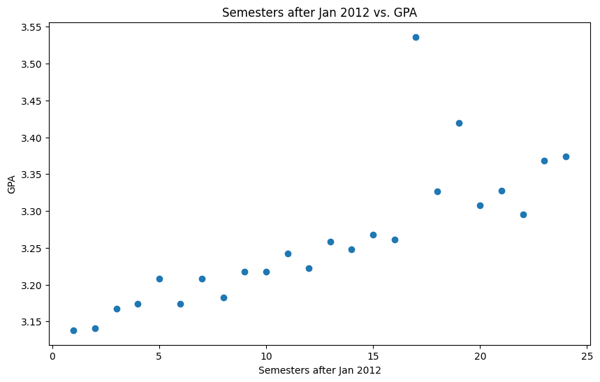

```python
semesters = [201201, 201208, 201301, 201308, 201401, 201408, 201501, 201508, 201601, 201608, 201701, 201708, 201801, 201808, 201901, 201908, 202001, 202008, 202101, 202108, 202201, 202208, 202301, 202308]
y_vals = []
semesters_after_Jan2012 = []


for x in semesters:
  filtered_rows = grades[grades['semester'] == x]
  mean_value = filtered_rows['gpa'].mean()
  y_vals.append(mean_value)

for x in semesters:
  semesters_after_Jan2012.append(semesters.index(x) + 1)


plt.figure(figsize=(10, 6))
plt.scatter(semesters_after_Jan2012, y_vals)
plt.title('Semesters after Jan 2012 vs. GPA')

plt.xlabel('Semesters after Jan 2012')
plt.ylabel('GPA')

plt.show()
```

### EDA Takeaways

Overall, while most of the graphs showing the distribution of different variables did not have any distinguishable patterns, there is a visible trend in GPAs over time using the grades dataframe, which aligns with PlanetTerp's previously reported information on grade inflation. In the next section, we will test the hypothesis ourselves with different machine learning techniques to examine the extent and nature of this relationship.

## Machine Learning and Hypothesis Testing

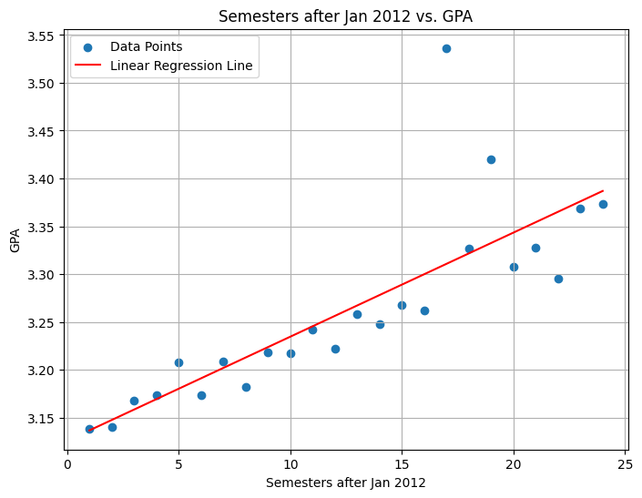

```python
regression_line = []

slope, intercept = np.polyfit(semesters_after_Jan2012, y_vals, 1)

# Create the regression line
for x in semesters_after_Jan2012:
    regression_line.append(slope * x + intercept)

# Plot the scatter plot
plt.figure(figsize=(8, 6))
plt.scatter(semesters_after_Jan2012, y_vals, label='Data Points')

# Plot the linear regression line
plt.plot(semesters_after_Jan2012, regression_line, color='red', label='Linear Regression Line')



plt.xlabel('Semesters after Jan 2012')
plt.ylabel('GPA')
plt.title('Semesters after Jan 2012 vs. GPA')
plt.legend()
plt.grid(True)
plt.show()
```

Another way to find a model for linear regression would be the sklearn LinearRegression() function, which uses ordinary least squares to fit the data.

```python
#Use sklearn LinearRegression()
X = np.array(semesters_after_Jan2012).reshape(-1, 1)

#Split randomly into train/test
X_train, X_test, y_train, y_test = train_test_split(X, y_vals, test_size=0.3)

reg = LinearRegression()
reg.fit(X_train, y_train)

y_pred = reg.predict(X_test)
mse = mean_squared_error(y_test, y_pred)
print("Validation MSE:", mse)
```

```
Validation MSE: 0.007416436447425498
```

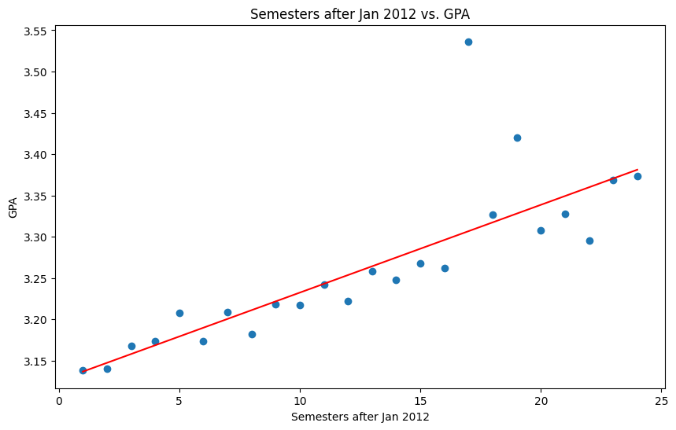

```python
plt.figure(figsize=(10, 6))
plt.scatter(semesters_after_Jan2012, y_vals)
plt.title('Semesters after Jan 2012 vs. GPA')

coefficients = reg.coef_
intercept = reg.intercept_
line_x = np.linspace(min(semesters_after_Jan2012), max(semesters_after_Jan2012), 100)
line_y = coefficients[0]*line_x + intercept
plt.plot(line_x, line_y, color='red')

plt.xlabel('Semesters after Jan 2012')
plt.ylabel('GPA')

plt.show()
```

Similar to linear regression, ridge regression works to find the optimal weights that would create a model that best fits the data. However, it avoids large coefficients, which are signs of overfitting to the data, by including a penalty term during calculation of the weights based on the L2 norm of the vector. This [blog post](https://www.analyticsvidhya.com/blog/2017/06/a-comprehensive-guide-for-linear-ridge-and-lasso-regression/) has a more in-depth description of ridge regression and other regression methods.

```python
#Use sklearn ridge regression with a quadratic term
squared_term = np.array(semesters_after_Jan2012)**2
squared_term = squared_term.reshape(-1, 1)
X = np.concatenate((squared_term, np.array(semesters_after_Jan2012).reshape(-1, 1)), axis=1)

#Split randomly into train/test
X_train, X_test, y_train, y_test = train_test_split(X, y_vals, test_size=0.3)

clf = Ridge(alpha=1.0, fit_intercept=True)
clf.fit(X_train, y_train)

y_pred = clf.predict(X_test)
mse = mean_squared_error(y_test, y_pred)
print("Validation MSE:", mse)
```

```
Validation MSE: 0.007528776764504963
```

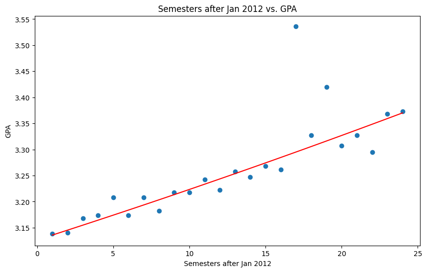

```python
plt.figure(figsize=(10, 6))
plt.scatter(semesters_after_Jan2012, y_vals)
plt.title('Semesters after Jan 2012 vs. GPA')

coefficients = clf.coef_
intercept = clf.intercept_
line_x = np.linspace(min(semesters_after_Jan2012), max(semesters_after_Jan2012), 100)
line_y = coefficients[0] * line_x**2 + coefficients[1]*line_x + intercept
plt.plot(line_x, line_y, color='red')

plt.xlabel('Semesters after Jan 2012')
plt.ylabel('GPA')

plt.show()
```

Based on the mean squared error for the randomly chosen validation set and the visual example of the model's performance, ridge regression with a quadratic term seems to perform well when used for training and validation for this dataset.

A third way of fitting a model is using [K-Nearest Neighbors](https://www.ibm.com/topics/knn) for regression. This method can be used for classification as well as regression tasks, and relies on the values of the k closest points or neighbors of a given point.

```
Validation MSE: 0.01026432141413936
```

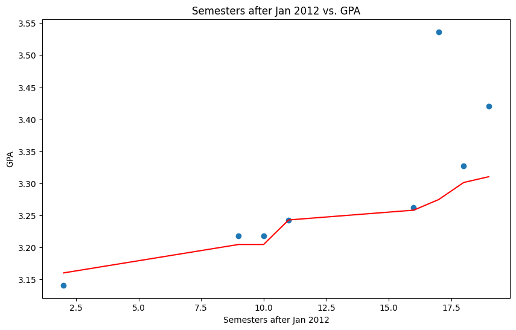

```python
#Use sklearn KNN
X = np.array(semesters_after_Jan2012).reshape(-1, 1)
X_train, X_test, y_train, y_test = train_test_split(X, y_vals, test_size=0.3)

num_neighbors = 3

knn = neighbors.KNeighborsRegressor(num_neighbors, weights="uniform")
knn.fit(X_train, y_train)

y_pred = knn.predict(X_test)
mse = mean_squared_error(y_test, y_pred)
print("Validation MSE:", mse)

plt.figure(figsize=(10, 6))
plt.scatter(X_test, y_test)
plt.title('Semesters after Jan 2012 vs. GPA')

indices = np.argsort(X_test.flatten())

# Use indices to sort both arrays
X_test_sorted = X_test.flatten()[indices]
y_pred_sorted = y_pred[indices]

plt.plot(X_test_sorted, y_pred_sorted, color='red')

plt.xlabel('Semesters after Jan 2012')
plt.ylabel('GPA')

plt.show()
```

All three of these models use different methods to fit a line to the data and have good results on randomly selected validation data based on the low mean squared error scores. We can use the ridge regression model to see what grades might look like in future semesters.

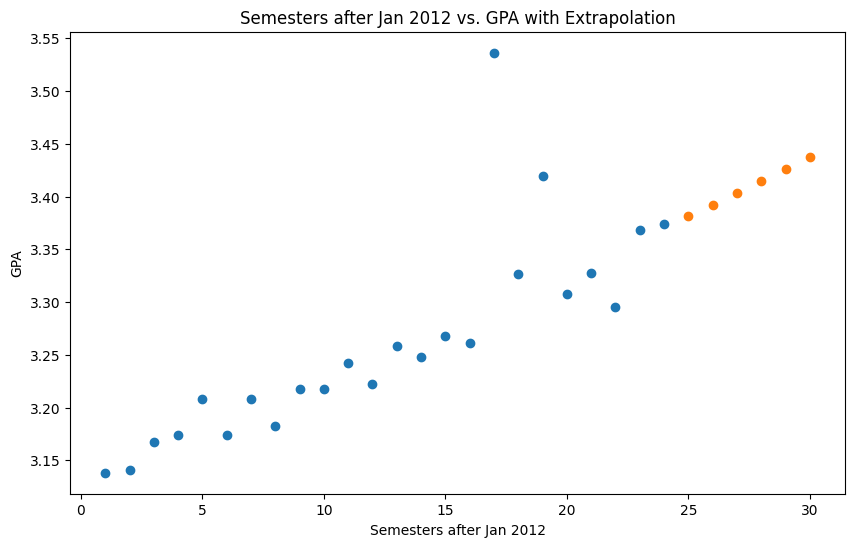

```python
plt.figure(figsize=(10, 6))
plt.scatter(semesters_after_Jan2012, y_vals)

plt.title('Semesters after Jan 2012 vs. GPA with Extrapolation')

#Use sklearn ridge regression with a quadratic term
squared_term = np.array([25, 26, 27, 28, 29, 30])**2
squared_term = squared_term.reshape(-1, 1)
X_test = np.concatenate((squared_term, np.array([25, 26, 27, 28, 29, 30]).reshape(-1, 1)), axis=1)

y_pred = clf.predict(X_test)
plt.scatter([x[1] for x in X_test], y_pred)

plt.xlabel('Semesters after Jan 2012')
plt.ylabel('GPA')

plt.show()
```

This is one estimation of what average university-wide semester GPAs in the future could look like, with the orange dots representing predicted values for semesters in the next few years. While it does not account for natural estimation and cannot be tested with ground truth labels, based on the accuracy of the models it seems to be a reasonable estimate of how grade inflation could continue in the future. PlanetTerp's interactive grade inflation visualization tool is available [here](https://planetterp.com/tools/gradeinflation).

## Conclusion and Interpretation

Overall, analysis of the data resulted in some interesting insights that show the value of the data science process. One takeaway is that student-generated data such as reviews and ratings can tend to be sparse and incomplete, and possible inaccuracies in the analysis could be due to these inconsistencies. However, data that is generated from public records such as grade and class data is useful for analysis since it is available to the public, and free APIs like what PlanetTerp provides allows for anyone to explore this data and find patterns.

The data in various tables during the collection and processing stage could be linked together to see the bigger picture about how features relating to grades, professors, courses, and reviews interact. While much of the exploratory data analysis showed that the data was too diverse and varied to see clear patterns, grade inflation was one trend that emerged. There is an important social aspect to this insight - if the average grade becomes higher and higher, the value of high GPAs may begin to decline. It might also become more difficult to appear competitive to employers compared to your peers based solely on grades. This raises of the question of what the best way to measure learning is, and if GPAs will continue to accurately gauge mastery of a subject once the average is sufficiently high. On the other hand, higher GPAs could also be because students are becoming better overall at learning and testing well on the skills learned in class. Time will tell if the trend continues and how it might affect higher education as a whole.

Regarding further exploration and analysis of this dataset, a potential idea for future expansion is sentiment analysis of reviews. With open source model repositories like [HuggingFace](https://huggingface.co/models) and libraries like [Scikit-Learn](https://scikit-learn.org/stable/modules/classes.html), it is easier than ever for people to explore and implement machine learning models as part of the data science process.

This tutorial is one example of how the steps of data collection, processing, exploratory analysis, hypothesis testing and machine learning can be applied to find insights about a particular dataset. The data science pipeline is versatile and can be generalized to any type of data, so it is worthwhile to experiment and see what new knowledge can be gained about different collections of information.